# Power Co Exploratory Analysis

#Libraries

```r
library(data.table)
library(RANN)
library(e1071)
source("functions.R")
```

```
RStudio Community is a great place to get help: https://community.rstudio.com/c/tidyverse.
```

#Load Data ## Data Summary

```r
data=fread('train/ml_case_training_data.csv')
output=fread('train/ml_case_training_output.csv')
hist=fread('train/ml_case_training_hist_data.csv')
summary(data)
```

```
      id            activity_new       campaign_disc_ele channel_sales         cons_12m         cons_gas_12m
 Length:16096       Length:16096       Mode:logical      Length:16096       Min.   : -125276   Min.   :  -3037
 Class :character   Class :character   NA's:16096        Class :character   1st Qu.:    5906   1st Qu.:      0
 Mode  :character   Mode  :character                     Mode  :character   Median :   15332   Median :      0
                                                                            Mean   :  194804   Mean   :  31912
                                                                            3rd Qu.:   50222   3rd Qu.:      0
                                                                            Max.   :16097108   Max.   :4188440

 cons_last_month    date_activ          date_end         date_first_activ   date_modif_prod    date_renewal
 Min.   : -91386   Length:16096       Length:16096       Length:16096       Length:16096       Length:16096
 1st Qu.:      0   Class :character   Class :character   Class :character   Class :character   Class :character
 Median :    901   Mode  :character   Mode  :character   Mode  :character   Mode  :character   Mode  :character
 Mean   :  19462
 3rd Qu.:   4127
 Max.   :4538720

 forecast_base_bill_ele forecast_base_bill_year forecast_bill_12m forecast_cons     forecast_cons_12m
 Min.   : -364.9        Min.   : -364.9         Min.   :-2503     Min.   :   0.00   Min.   :-16689.3
 1st Qu.:    0.0        1st Qu.:    0.0         1st Qu.: 1158     1st Qu.:   0.00   1st Qu.:   513.2
 Median :  163.0        Median :  163.0         Median : 2187     Median :  42.22   Median :  1179.2
 Mean   :  335.8        Mean   :  335.8         Mean   : 3837     Mean   : 206.84   Mean   :  2370.6
 3rd Qu.:  396.2        3rd Qu.:  396.2         3rd Qu.: 4247     3rd Qu.: 228.12   3rd Qu.:  2692.1
 Max.   :12566.1        Max.   :12566.1         Max.   :81123     Max.   :9682.89   Max.   :103801.9
 NA's   :12588          NA's   :12588           NA's   :12588     NA's   :12588
 forecast_cons_year forecast_discount_energy forecast_meter_rent_12m forecast_price_energy_p1
 Min.   :-85627     Min.   : 0.0000          Min.   :-242.96         Min.   :0.0000
 1st Qu.:     0     1st Qu.: 0.0000          1st Qu.:  16.23         1st Qu.:0.1152
 Median :   378     Median : 0.0000          Median :  19.44         Median :0.1429
 Mean   :  1907     Mean   : 0.9916          Mean   :  70.31         Mean   :0.1359
 3rd Qu.:  1994     3rd Qu.: 0.0000          3rd Qu.: 131.47         3rd Qu.:0.1464
 Max.   :175375     Max.   :50.0000          Max.   :2411.69         Max.   :0.2740
                    NA's   :126                                      NA's   :126
 forecast_price_energy_p2 forecast_price_pow_p1   has_gas             imp_cons        margin_gross_pow_ele
 Min.   :0.00000          Min.   :-0.1222       Length:16096       Min.   :-9038.21   Min.   :-525.54
 1st Qu.:0.00000          1st Qu.:40.6067       Class :character   1st Qu.:    0.00   1st Qu.:  11.96
 Median :0.08616          Median :44.3114       Mode  :character   Median :   44.47   Median :  21.09
 Mean   :0.05295          Mean   :43.5335                          Mean   :  196.12   Mean   :  22.46
 3rd Qu.:0.09884          3rd Qu.:44.3114                          3rd Qu.:  218.09   3rd Qu.:  29.64
 Max.   :0.19598          Max.   :59.4447                          Max.   :15042.79   Max.   : 374.64
 NA's   :126              NA's   :126                                                 NA's   :13
 margin_net_pow_ele  nb_prod_act       net_margin       num_years_antig   origin_up            pow_max
 Min.   :-615.66    Min.   : 1.000   Min.   :-4148.99   Min.   : 1.000   Length:16096       Min.   :  1.00
 1st Qu.:  11.95    1st Qu.: 1.000   1st Qu.:   51.97   1st Qu.: 4.000   Class :character   1st Qu.: 12.50
 Median :  20.97    Median : 1.000   Median :  119.68   Median : 5.000   Mode  :character   Median : 13.86
 Mean   :  21.46    Mean   : 1.348   Mean   :  217.99   Mean   : 5.031                      Mean   : 20.60
 3rd Qu.:  29.64    3rd Qu.: 1.000   3rd Qu.:  275.81   3rd Qu.: 6.000                      3rd Qu.: 19.80
 Max.   : 374.64    Max.   :32.000   Max.   :24570.65   Max.   :16.000                      Max.   :500.00
 NA's   :13                          NA's   :15                                             NA's   :3
```

We can see a lot of missing values, the dataset must handle those case before any modeling can begin.

Let’s take a look at the target variable

```r
table(output$churn)
```

```
    0     1
14501  1595
```

We have umbalanced classes and we should undersample the data in order to prevent it from skewing the results. But first, let’s keep 30% of our data aside in order to have fresh data for the validation procedure.

# Validation Partitioning

```r
set.seed(814)
full_train_index=createDataPartition(output$churn,p=0.7,list = F)
full_train_data=data[full_train_index]
test_data=data[-full_train_index]
dim(full_train_data)
```

```
[1] 11268    32
```

# Basic Cleaning

Let’s us build a basic clean dataset before undersampling it. This consists in converting dates, one_encoding categorical variables, and other minor feature transformations.

```r
clean_data=preprocess_train_pipeline(full_train_data,cleanOnly = T)
```

```
[1] "Remove Zero Variance columns and split columns by type"
[1] "-------ok"
[1] "Train data structure"
[1] "-------ok"
[1] "Train one Hot Encode of categorical columns"
[1] "-------ok"
[1] "Predict data structure"
[1] "-------ok"
[1] "Predict one Hot Encode of categorical columns"
[1] "-------ok"
[1] "Merge Binary data"
[1] "-------ok"
```

```r
cdata=cbindlist(clean_data$data$output,append = T)
dim(cdata)
```

```
[1] 11268   417
```

Now we have over 417 dimensions to deal with. The categorical variables have been transformed and each category have been assigned to a new binary variable. To make column selection easier each variable had it’s name preappended according to its origin

```r
unique(sapply(strsplit(names(cdata),split="\\."),function(s) s[[1]]))
```

```
[1] "id"                       "binary"                   "na_values"                "one_hot_categorical_data"
```

# Undersampling partitions

```r
set.seed(815)
source("partition.R")
part=data_partition(full_train_data,output[full_train_index]$churn,k=11)
sampled_binary=part$apply(part,clean_data$data$combined$binaries,y=T)
lapply(sampled_binary,dim)
```

```
$Resample.1
[1] 2218  417

$Resample.2
[1] 2218  417

$Resample.3
[1] 2218  417

$Resample.4
[1] 2218  417

$Resample.5
[1] 2218  417

$Resample.6
[1] 2218  417

$Resample.7
[1] 2218  417

$Resample.8
[1] 2218  417

$Resample.9
[1] 2218  417

$Resample.10
[1] 2218  417

$Resample.11
[1] 2218  417
```

We chose to undersample before making any descriptive analysis to prevent long tailed distribuition from skewing results due to the large samples of a specific class.

Let’s see which are the top 10 binary values with great jaccard similarity with our target variable: # Similarities

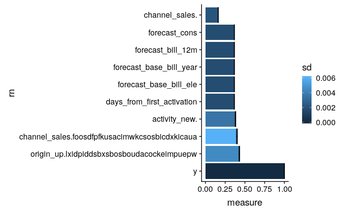

These results were averaged out of 11 resamplings.

#Accuracy

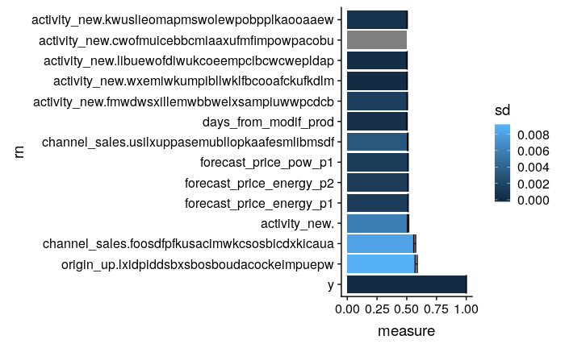

```r
part$measure(sampled_binary,accuracy)
```

Now let’s look at time dependence of the average of our target variable:

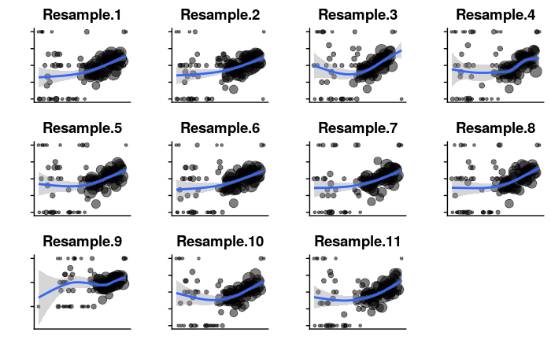

```r
sampled_values=part$apply(part,clean_data$data$raw$values,y=T)
plots=data_partition.regression(sampled_values)
plot_grid(plotlist=plots)
```

From the last couple of years we can see a linear increase in the probability of churn with time. The means that recent activation users are more likely to churn.

```
Ignoring unknown parameters: binwidth, bins, pad
```

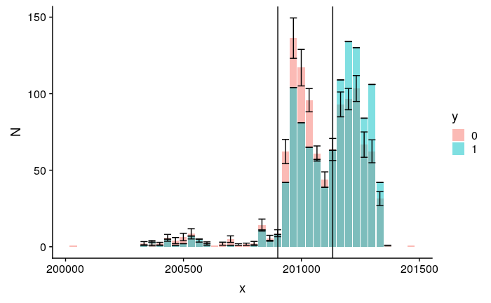

```r
ggplot(hist.sampled,aes(x=x,y=N,fill=y,ymax=Nmax,ymin=Nmin))+
  geom_histogram(stat='identity',position='identity',alpha=0.5)+
  geom_errorbar()+geom_vline(xintercept=200900)+geom_vline(xintercept=201133)
```

```
Ignoring unknown parameters: binwidth, bins, pad
```

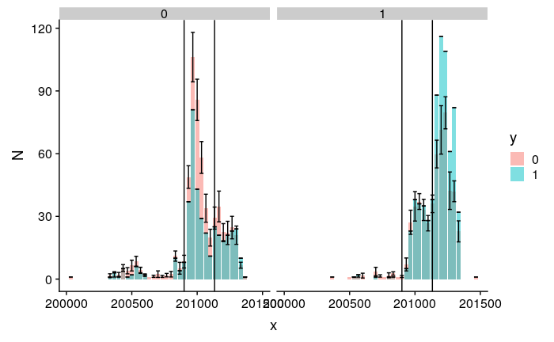

```r
ggplot(hist.sampled_origin,aes(x=x,y=N,fill=y,ymax=Nmax,ymin=Nmin))+
  geom_histogram(stat='identity',position='identity',alpha=0.5)+
  geom_errorbar()+geom_vline(xintercept=200900)+geom_vline(xintercept=201133)+facet_wrap(~origin)
```

```
Ignoring unknown parameters: binwidth, bins, pad
```

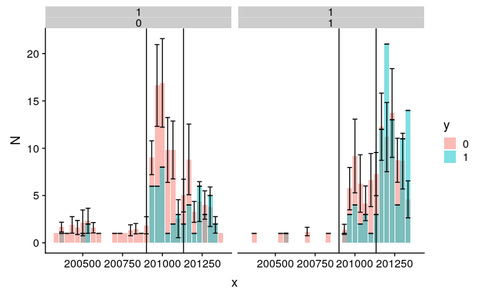

```r
ggplot(hist.sampled_origin[has_gas==1],aes(x=x,y=N,fill=y,ymax=Nmax,ymin=Nmin))+
  geom_histogram(stat='identity',position='identity',alpha=0.5)+
  geom_errorbar()+geom_vline(xintercept=200900)+geom_vline(xintercept=201133)+facet_wrap(has_gas~origin)
```

```r
idata=predict_preprocess_model(imput_data,full_train_data)
```

```
[1] "Predict data structure"
[1] "-------ok"
[1] "Predict one Hot Encode of categorical columns"
[1] "-------ok"
[1] "Predict Imput data"
[1] "-------ok"
[1] "Merge Binary data"
[1] "-------ok"
```

Let’s see if the energy price follows the same trend:

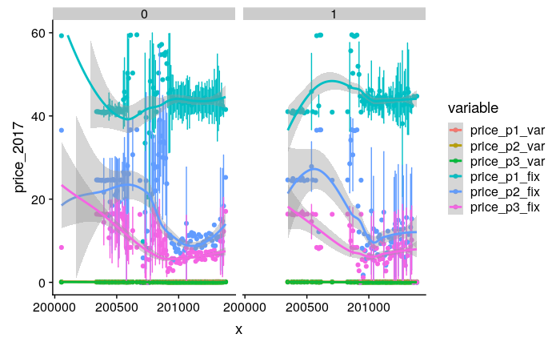

```r
dt=cbind(clean_data$data$output$id,clean_data$data$raw$values)
dt=merge(dt,output,by='id')
clean_hist=hist
clean_hist[,price_date:= as.Date(price_date,format="%Y-%m-%d")]
clean_hist=melt(clean_hist,id.vars=c('id','price_date'))
clean_hist[,sd:=sd(value),.(variable,id)]

forecast=clean_hist[sd > 0][,.(price_2017=predict(lm(value ~ price_date),newdata = data.table(price_date=as.Date("2017-01-01")))),.(id,variable)]
still_price_forecast=clean_hist[sd == 0][, .(price_2017=mean(value,na.rm=T)),.(id,variable)]
full_forecast=rbind(forecast,still_price_forecast)
avg_price_forecast=clean_hist[, .(avg_price_2015=mean(value,na.rm=T)),.(id,variable)]
full_forecast=merge(full_forecast,avg_price_forecast,by=c('id','variable'))
forecast_values=merge(full_forecast,dt,by='id',all=F)

origin=cbind(clean_data$data$output$id,clean_data$data$combined$binaries[,.(origin=origin_up.lxidpiddsbxsbosboudacockeimpuepw)])
forecast_values=merge(forecast_values,origin,by='id',all=F)

dt_plot=forecast_values[,.(.N,price_2017=mean(price_2017),sd=sd(price_2017)) ,.(x=activ_year*100+(activ_month/12-0.5/12)*100,variable,churn)]
ggplot(dt_plot,aes(x=x,y=price_2017,ymin=price_2017-sd,ymax=price_2017+sd,color=variable,weight=N))+geom_point()+geom_errorbar()+geom_smooth()+facet_grid(~churn)+ylim(0,60)
```

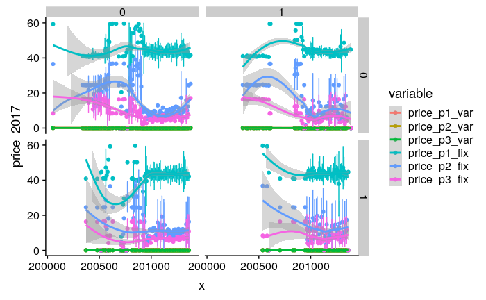

```r
dt_plot=forecast_values[,.(.N,price_2017=mean(price_2017),sd=sd(price_2017)) ,.(x=activ_year*100+(activ_month/12-0.5/12)*100,variable,churn,origin)]
ggplot(dt_plot,aes(x=x,y=price_2017,ymin=price_2017-sd,ymax=price_2017+sd,color=variable,weight=N))+geom_point()+geom_errorbar()+geom_smooth()+facet_grid(origin~churn)+ylim(0,60)
```

```
Ignoring unknown parameters: binwidth, bins, pad
```

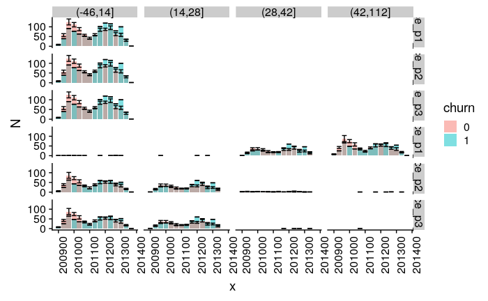

```r
forepart=part$apply(part,forecast_values,y=T,by.id=T)
forefunc=function(foreplot,name){
foreplot=foreplot[activ_year > 2008,.(N=length(unique(id))),.(x=activ_year*100+floor(activ_month/4-0.25)*4/12*100,
variable,                                                        price_2017=cut(price_2017,c(-46,14,28,42,112)),churn=as.factor(churn))]
foreplot$name=name
foreplot
}
foremerge=rbindlist(lapply(names(forepart),function(name) forefunc(forepart[[name]],name)))
foremerge=foremerge[,.(Nsd=sd(N),N=mean(N)),.(x,variable,price_2017,churn)]
ggplot(foremerge,aes(x=x,y=N,fill=churn,ymin=N-Nsd,ymax=N+Nsd))+
  geom_histogram(stat='identity',position='identity',alpha=0.5)+geom_errorbar()+
  facet_grid(variable ~price_2017)+ theme(axis.text.x = element_text(angle = 90, hjust = 1))
```

```
Ignoring unknown parameters: binwidth, bins, pad
```

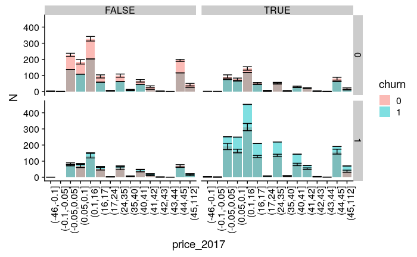

```r
forepart=part$apply(part,forecast_values,y=T,by.id=T)
forefunc=function(foreplot,name){
foreplot=foreplot[activ_year > 2008,.(N=length(unique(id))),.(x=activ_year > 2011 | activ_year == 2011 & activ_month > 3,
price_2017=cut(price_2017,c(-46,-0.1,-0.05,0.05,0.1,16:17,24,35,40:45,112)),churn=as.factor(churn),origin)]
foreplot$name=name
foreplot
}
foremerge=rbindlist(lapply(names(forepart),function(name) forefunc(forepart[[name]],name)))
foremerge=foremerge[,.(Nsd=sd(N),N=mean(N)),.(x,price_2017,churn,origin)]
ggplot(foremerge,aes(x=price_2017,y=N,fill=churn,ymin=N-Nsd,ymax=N+Nsd))+
  geom_histogram(stat='identity',position='identity',alpha=0.5)+geom_errorbar()+
  facet_grid(origin~x )+ theme(axis.text.x = element_text(angle = 90, hjust = 1))
```

```
Ignoring unknown parameters: binwidth, bins, pad
```

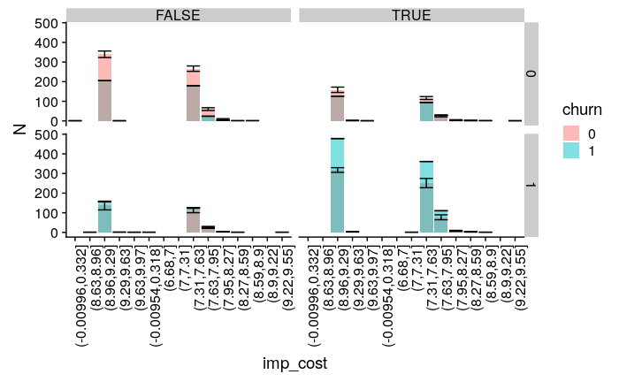

```r
forepart=part$apply(part,forecast_values,y=T,by.id=T)
forefunc=function(foreplot,name){
foreplot=foreplot[activ_year > 2008,
                  .(N=length(unique(id))),
                  .(x=activ_year > 2011 | activ_year == 2011 & activ_month > 3,
                    imp_cost=cut(log(imp_cons-min(imp_cons)+1),30),
                    churn=as.factor(churn),
                    origin)]
foreplot$name=name
foreplot
}
foremerge=rbindlist(lapply(names(forepart),function(name) forefunc(forepart[[name]],name)))
foremerge=foremerge[,.(Nsd=sd(N),N=mean(N)),.(x,origin,imp_cost,churn)]
ggplot(foremerge,aes(x=imp_cost,y=N,fill=churn,ymin=N-Nsd,ymax=N+Nsd))+
  geom_histogram(stat='identity',position='identity',alpha=0.5)+geom_errorbar()+
  facet_grid(origin~x )+ theme(axis.text.x = element_text(angle = 90, hjust = 1))
```

Not much help, we should look for the price distribuition if it changes over time.

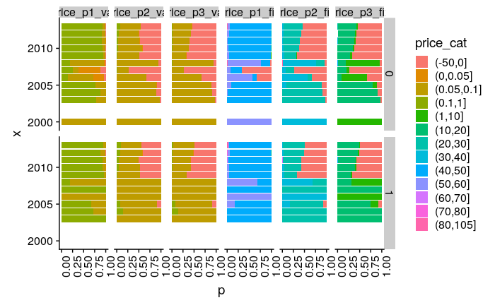

```r
dt_cat_plot=forecast_values[,.(price_cat=(as.character(cut(price_2017,4))),activ_year,activ_month,id,churn),variable]
dt_cat_plot=forecast_values[,.(price_cat=cut(price_2017,breaks=c(-50,0,0.05,0.1,1,10,20,30,40,50,60,70,80,105)),activ_year,activ_month,id,churn,variable)]

dt_cat_plot=dt_cat_plot[,.N ,.(x=activ_year,variable,price_cat,churn)]
dt_cat_plot=dt_cat_plot[,.(p=N/sum(N),price_cat) ,.(x,variable,churn)]

ggplot(dt_cat_plot,aes(x=x,y=p,fill=price_cat))+geom_bar(stat='identity')+facet_grid(churn~variable)+coord_flip()+ theme(axis.text.x = element_text(angle = 90, hjust = 1))
```

Does gas_consumtion is a confounding variable?

```
NaNs produced
```

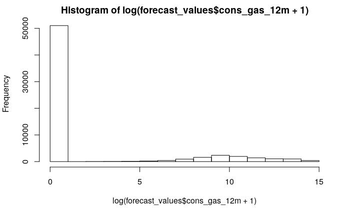

```r
hist(log(forecast_values$cons_gas_12m+1))
```

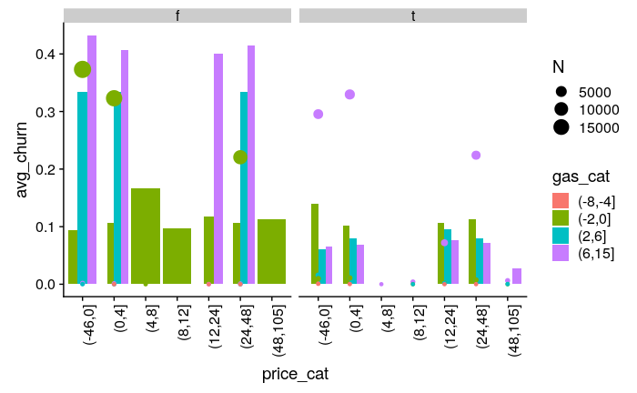

```r
gas_values=merge(forecast_values,data[,.(id,has_gas)],by='id')
dt_plot=gas_values[,.(.N,avg_churn=mean(churn)),.(price_cat=cut(price_2017,breaks = c(-46,0,4,8,12,24,48,105)),gas_cat=cut(transform_gas(cons_gas_12m),c(-8,-4,-2,0,1,2,6,15)),has_gas)]
dt_plot=dt_plot[,.(N,p=N/sum(N),avg_churn,gas_cat,price_cat),has_gas]
ggplot(dt_plot,aes(x=price_cat,y=avg_churn,fill=gas_cat))+geom_bar(stat='identity',position='dodge')+facet_wrap(~has_gas)+ theme(axis.text.x = element_text(angle = 90, hjust = 1))+geom_point(aes(y=p,color=gas_cat,size=N))
```

#Let’s see the difference between the churn distribuition across prices, time and if it is a gas client.

```r
dt_cat_plot=gas_values[,.(price_cat=cut(price_2017,breaks=c(-50,0,0.05,0.1,1,10,20,30,40,50,60,70,80,105)),has_gas,activ_year,activ_month,id,churn,variable)]

dt_cat_plot=dt_cat_plot[,.N ,.(x=activ_year,variable,price_cat,churn,has_gas)]
dt_cat_plot=dt_cat_plot[,.(N,p=N/sum(N),price_cat) ,.(x,variable,churn,has_gas)]

delta_plot=merge(dt_cat_plot[churn==0 ,-c("churn")],dt_cat_plot[churn==1][,-c("churn")],by=c("x","variable","price_cat","has_gas"),all=T)
delta_plot[!complete.cases(delta_plot)]
```

| x | variable | price_cat | has_gas | N.x | p.x | N.y | p.y |
| --- | --- | --- | --- | --- | --- | --- | --- |
| 2000 | price_p1_var | (0.05,0.1] | f | 1 | 1.0000000000 | NA | NA |
| 2000 | price_p2_var | (0.05,0.1] | f | 1 | 1.0000000000 | NA | NA |
| 2000 | price_p3_var | (0.05,0.1] | f | 1 | 1.0000000000 | NA | NA |
| 2000 | price_p1_fix | (50,60] | f | 1 | 1.0000000000 | NA | NA |
| 2000 | price_p2_fix | (30,40] | f | 1 | 1.0000000000 | NA | NA |
| 2000 | price_p3_fix | (1,10] | f | 1 | 1.0000000000 | NA | NA |
| 2003 | price_p1_var | (0.05,0.1] | f | 3 | 0.1363636364 | NA | NA |
| 2003 | price_p1_var | (0.05,0.1] | t | 4 | 0.4000000000 | NA | NA |
| 2003 | price_p2_var | (-50,0] | t | 1 | 0.1000000000 | NA | NA |
| 2003 | price_p3_var | (-50,0] | t | 1 | 0.1000000000 | NA | NA |

[output cut: 219 more lines]

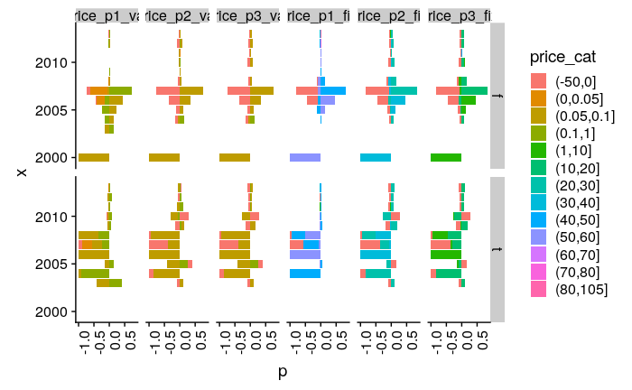

```r
delta_plot[is.na(p.x)]$p.x=0
delta_plot[is.na(p.y)]$p.y=0
delta_plot[,p:=p.y-p.x]

ggplot(delta_plot,aes(x=x,y=p,fill=price_cat))+geom_bar(stat='identity')+facet_grid(has_gas~variable)+coord_flip()+theme(axis.text.x = element_text(angle = 90, hjust = 1))
```

These cannot explain the increase in churn in the recent years.

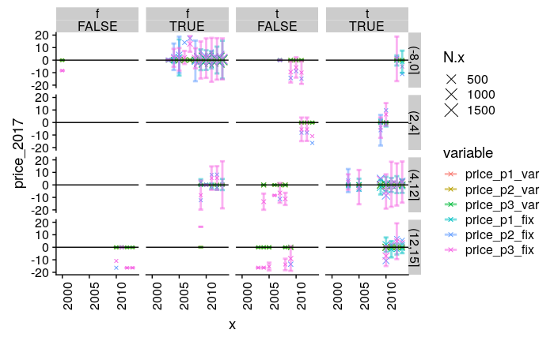

```r
adt_plot=gas_values[,.(.N,price_2017=mean(price_2017),sd=sd(price_2017)) ,.(x=activ_year+0*(activ_month/12-0.5/12)*100,variable,churn,has_gas,
                                                                         gas_cat=cut(transform_gas(cons_gas_12m),c(-8,0,1,2,4,12,15)))]
dt_plot=merge(adt_plot[churn==0],adt_plot[churn==1],all=T,by=c('x','variable','has_gas','gas_cat'))
dt_plot[is.na(price_2017.x)]$price_2017.x =0
dt_plot[is.na(price_2017.y)]$price_2017.y =0
dt_plot[is.na(sd.x)]$sd.x =0
dt_plot[is.na(sd.y)]$sd.y =0

dt_plot[,price_2017:=price_2017.y- price_2017.x]
dt_plot[,sd:=sd.y + sd.x]
dt_plot[,has_churn:=!is.na(churn.y)]
ggplot(dt_plot,aes(x=x,y=price_2017,ymin=price_2017-sd,ymax=price_2017+sd,color=variable,size=N.x),shape=4)+geom_point(shape=4)+geom_errorbar(size=1,alpha=0.5)+
  facet_grid(gas_cat~has_gas+has_churn)+theme(axis.text.x = element_text(angle = 90, hjust = 1))+geom_hline(yintercept=0)+ylim(-20,20)
```

```r
dt_plot[,sum((price_2017 > 0 )*N.x,na.rm=T)/sum(N.x,na.rm=T)]
```

```
[1] 0.7971499
```

80% of churns have average price above the normal average.

TODO : calculate price increase

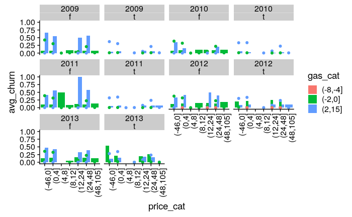

```r
gas_values=merge(forecast_values,data[,.(id,has_gas)],by='id')
dt_plot=gas_values[activ_year >= 2009,.(.N,avg_churn=mean(churn)),.(x=activ_year,price_cat=cut(price_2017,breaks = c(-46,0,4,8,12,24,48,105)),gas_cat=cut(transform_gas(cons_gas_12m),c(-8,-4,-2,0,1,2,15)),has_gas)]
dt_plot=dt_plot[,.(N,p=N/sum(N),price_cat,gas_cat,avg_churn),.(x,has_gas)]
ggplot(dt_plot,aes(x=price_cat,y=avg_churn,fill=gas_cat))+geom_bar(stat='identity',position='dodge')+geom_point(aes(y=p,color=gas_cat))+
  facet_wrap(x~has_gas)+ theme(axis.text.x = element_text(angle = 90, hjust = 1))
```

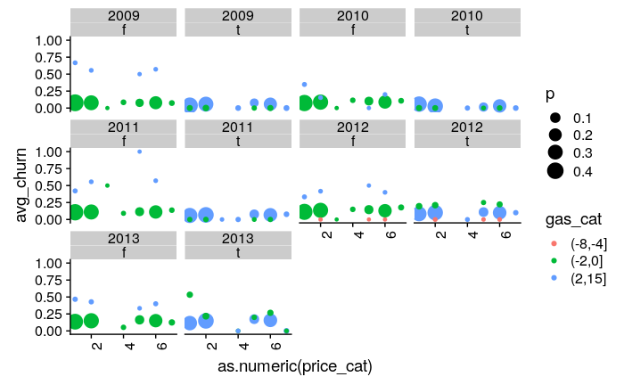

```r
gas_values=merge(forecast_values,data[,.(id,has_gas)],by='id')
dt_plot=gas_values[activ_year >= 2009,.(.N,avg_churn=mean(churn)),.(x=activ_year,price_cat=cut(price_2017,breaks = c(-46,0,4,8,12,24,48,105)),gas_cat=cut(transform_gas(cons_gas_12m),c(-8,-4,-2,0,1,2,15)),has_gas)]
dt_plot=dt_plot[,.(N,p=N/sum(N),price_cat,gas_cat,avg_churn),.(x,has_gas)]
ggplot(dt_plot,aes(x=as.numeric(price_cat),y=avg_churn,color=gas_cat,size=p))+geom_point()+
  facet_wrap(x~has_gas)+ theme(axis.text.x = element_text(angle = 90, hjust = 1))
```

```
NaNs produced
```

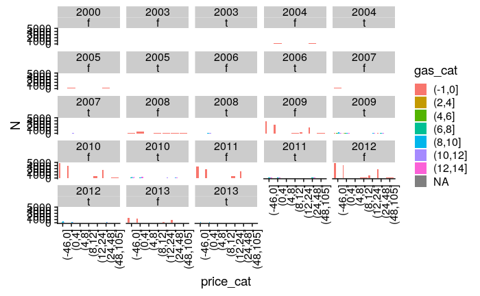

```r
gas_values=merge(forecast_values,data[,.(id,has_gas)],by='id')
ggplot(gas_values[,.(.N,avg_churn=mean(churn)),.(x=activ_year,price_cat=cut(price_2017,breaks = c(-46,0,4,8,12,24,48,105)),gas_cat=cut(log(cons_gas_12m+1),c(-1,0,1,2,4,6,8,10,12,14)),has_gas)],aes(x=price_cat,y=N,fill=gas_cat))+geom_bar(stat='identity',position='dodge')+facet_wrap(x~has_gas)+ theme(axis.text.x = element_text(angle = 90, hjust = 1))
```

```r
gas_values[,summary(transform_gas(cons_gas_12m))]
```

```
   Min. 1st Qu.  Median    Mean 3rd Qu.    Max.
 -7.874   0.000   0.000   1.862   0.000  14.850
```

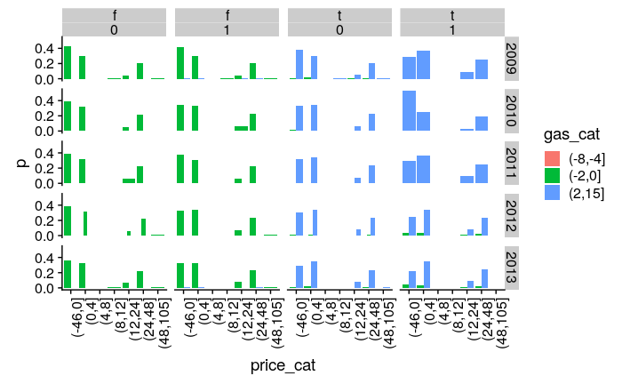

```r
dt_plot=gas_values[activ_year >= 2009,.N,.(x=activ_year,price_cat=cut(price_2017,breaks = c(-46,0,4,8,12,24,48,105)),gas_cat=cut(transform_gas(cons_gas_12m),c(-8,-4,-2,0,1,2,15)),has_gas,churn)]
dt_plot=dt_plot[,.(N,p=N/sum(N),price_cat,gas_cat),.(x,has_gas,churn)]
ggplot(dt_plot,aes(x=price_cat,y=p,fill=gas_cat))+geom_bar(stat='identity',position='dodge')+
facet_grid(x~has_gas+churn)+ theme(axis.text.x = element_text(angle = 90, hjust = 1))
```

```r
#+geom_line(aes(y=p,x=as.numeric(price_cat),color=gas_cat))+
```

```r
preprocess_model=preprocess_train_pipeline(data)
```

```
[1] "Remove Zero Variance columns and split columns by type"
[1] "-------ok"
[1] "Train data structure"
[1] "-------ok"
[1] "Train one Hot Encode of categorical columns"
[1] "-------ok"
[1] "Train imput model"
[1] "-------ok"
[1] "Predict data structure"
[1] "-------ok"
[1] "Predict one Hot Encode of categorical columns"
[1] "-------ok"
[1] "Predict Imput data"
[1] "-------ok"
[1] "Merge Binary data"
[1] "-------ok"
[1] "Training Binary PCA"
[1] "Training Continuous PCA"
```

```r
save(preprocess_model,file="preprocessing.model.RData")
```

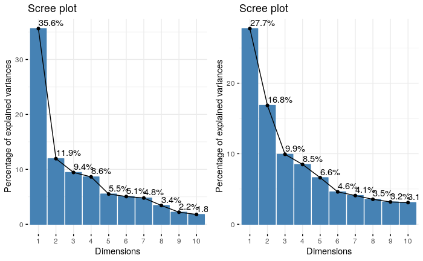

```r
load("preprocessing.model.RData")
plot_explain_variance(preprocess_model)
```

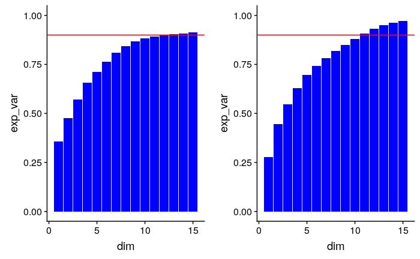

```r
plot_cum_explain_variance(preprocess_model)
```

# Let’s see how accurate pca can reconstruct the binary matrix with just 15 dimensions

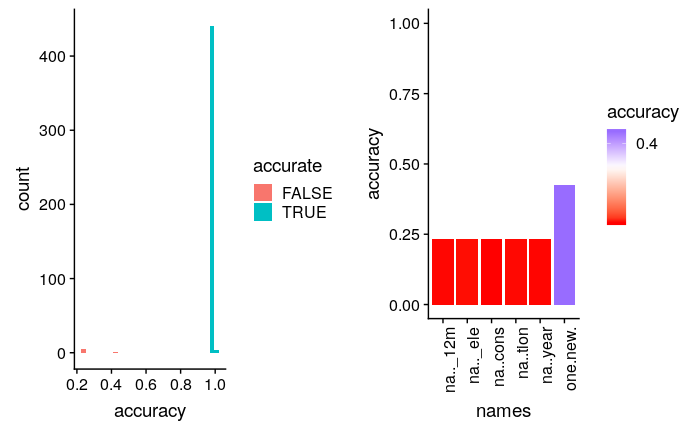

```r
plot_grid(plotlist=list(ret[[2]],ret[[3]]))
```

# Are the low accuracy columns those correlated?

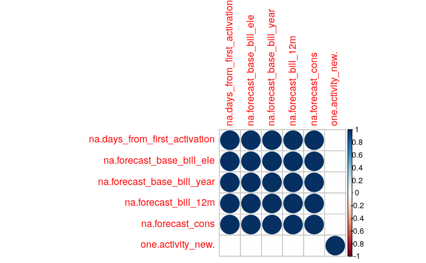

```
Removed 2 rows containing missing values (geom_bar).
```

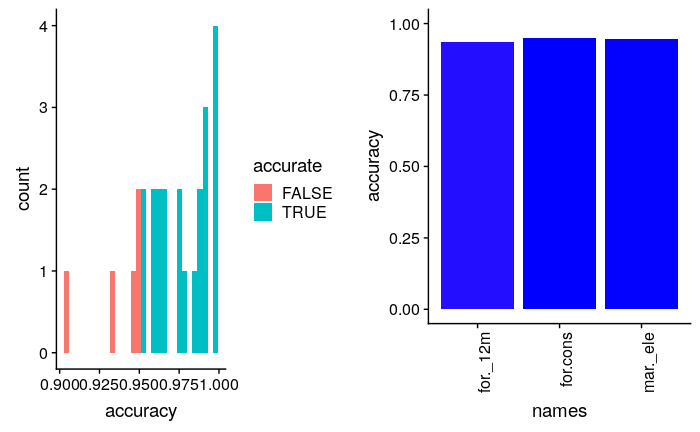

```r
plot_grid(plotlist=list(ret[[2]],ret[[3]]))
```

# Are the low accuracy columns those correlated?

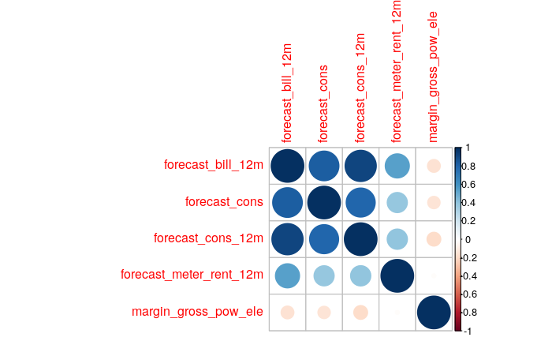